# SWOMSE User Manual

# 3 Management Strategy Evaluation

The `runMSE` function is used to run a management strategy evaluation.

To run an MSE we need to provide `runMSE` with an operating model and the names of the MPs we wish to test.

## 3.1 Conditioning OM with Data

In default mode, `runMSE` will generate ‘observed’ fishery data from the population dynamics that are simulated with the parameters in the OM.

To ensure that the simulated index in `Data@Ind` is the same as our actual index, we must provide the OM with our fishery data object:

```r
SWOM@cpars$Data <- SWOData
```

Now the index in the simulated Data object used in the MSE will exactly match the index in our `Data` object.

The statistical properties of the index (i.e., hyper-stability parameter and variance) are calculated by comparing the standardized index with the simulated population, and these observation error parameters are used to generate comparable index values for the future projection years.

The same concept applies for any additional indices that may be present in `Data@AddInd`.

## 3.2 Performance Metrics

Before running the MSE it is important to develop performance statistics that will be used to evaluate the performance of the different management procedures.

The `SWOMSE` package follows the `DLMtool` and `MSEtool` packages in using standardized functions of class `PM` to calculate performance metrics.

We can use either the available Performance Metrics methods from the `DLMtool` and `MSEtool` packages, or create our own custom functions of class `PM`.

### 3.2.1 `DLMtool` Package PMs

In this demonstration we will use three of the built-in PM functions from the `DLMtool` and `MSEtool` packages and create two of our own.

The three PMs from the `DLMtool` package:

- `AAVY` - the probability that the average annual variability in yield is less than 20%
- `P50` - the probability that spawning biomass $(\text{SB})$ is greater than $0.5\text{SB}_{\text{MSY}}$
- `PNOF` - the probability that fishing mortality ($F$) is less than $F_\text{MSY}$

By default these performance statistics are calculated over all projection years, although it is straightforward to modify this assumption.

### 3.2.2 `SWOMSE` Package PMs

Two custom PMs are included in the `SWOMSE` package: the average yield in the first 10 years (short-term catch; `STC`) and in the last 10 years (long-term catch; `LTC`) of the projection period.

```r
avail("PM")
```

```
#> [1] "STC" "LTC"
```

### 3.2.3 Custom PMs

Similiar to MPs, it is straightforward to create custom `PM` functions. The [`DLMtool` user manual](https://dlmtool.github.io/DLMtool/userguide/custom-performance-metrics.html) describes how to create custom `PM` functions and use them in the MSE analysis.

## 3.3 More details on the Operating Model

Some final details on the Operating Model before we run an example MSE.

### 3.3.1 Observation and Implementation Error

As mentioned earlier, in addition to the parameters for the stock and fleet dynamics, the Operating Model also includes parameters for observation and implementation processes.

For purposes of demonstration the `OM` objects in the `SWOMSE` package assume very little observation error and no implementation error; for example:

```r
SWOM@Mbiascv # no uncertainty in natural mortality parameter (observation error)
```

```
#> [1] 0.01
```

```r
SWOM@TACFrac # TACs are assumed to be caught exactly (implementation error)
```

```
#> [1] 1 1
```

Note that because we provided the real `Data` object in the `SWOM` object, the catch and index observation parameters are calculated internally and the relevant values in the `OM` (catch: `SWOM@Cobs` and `SWOM@Cbias` and index: `SWOM@beta` and `SWOM@Iobs`) are ignored.

Alternative assumptions for observation or implementation error can be included by modifying the values in the relevant slots, or by replacing the Observation and/or Implementation parameters with other built-in parameter sets, for example:

```r
avail("Obs", "all") # all availabe Observation parameter sets
```

```
#> [1] "Generic_Obs"        "Imprecise_Biased"   "Imprecise_Unbiased"
#> [4] "Perfect_Info"       "Precise_Biased"     "Precise_Unbiased"
```

```r
# create new OM with Imprecise and Biased observation parameters
SWOM_impbiased <- Replace(SWOM, Imprecise_Biased)
```

```
#> Replacing sub-model: Obs
```

```r
avail("Imp", "all") # all availabe Implementation parameter sets
```

```
#> [1] "Overages"    "Perfect_Imp"
```

```r
# create new OM with TAC overage implementation parameters
SWOM_overage <- Replace(SWOM, Overages)
```

```
#> Replacing sub-model: Imp
```

### 3.3.2 Projection Period & Management Interval

The number of projection years in is specified with the `proyears` slot in the `OM` object. In this case, the OMs in the `SWOMSE` package include a 50-year projection period:

```r
SWOM@proyears
```

```
#> [1] 50
```

We can decrease the number of projection years by changing the value in `SWOM@proyears` to a smaller value.

However, because the OMs were created directly from SS OMs using the `SWO_SS2OM` function, we cannot increase the number of projection years without re-importing the SS OMs.

The `OM@interval` slot species the management interval. For example, the OMs in the `SWOMSE` package have a `interval` value of 1, which means that the MPs will be applied every 1 years, with the TAC held constant in the interim years.

Similiar to the `proyears` argument, we can easily change the management interval by setting the value in `SWOM@interval` to any positive integer value.

## 3.4 Running the MSE

We now have everything to run an example MSE:

- operating model: `SWOM`, conditioned with `SWOData`
- MPs: `avail("MP")`

Remember, the `SWOM` has 174 simulations (`SWOM@nsim`): corresponding to the base case SS OM, and the 173 SS OMs from the uncertainty grid. This means that the MSE will generate 174 simulations in every time-step, and simultaneously apply the MPs to all simulations.

Because there are a large number of simulations we will run the MSE using parallel processing (`parallel=TRUE`). Update messages are not available in parallel mode, but the MSE runs substantially quicker when using parallel mode.

Set up parallel processing:

```r
setup()
```

And run the MSE (may take a few minutes):

```r
MPs <- c('AverageC', 'ConstC', 'Itarg1', 'Itarg2',
         'FMSYref', 'SP_4010')# the MPs that will be run
SWOM@cpars$Data <- SWOData # for clarity, re-add SWOData to the OM

SWO_MSE <- runMSE(SWOM, MPs=MPs, parallel = TRUE)
```

The `runMSE` function returns the completed MSE in an object of class `MSE`:

```r
class(SWO_MSE)
```

```
#> [1] "MSE"
#> attr(,"package")
#> [1] "DLMtool"
```

## 3.5 Examining MSE Results

Now that the MSE is complete we can evaluate the MPs with our performance metrics.

### 3.5.1 Convergence Diagnostics

First we will confirm that the MSE has converged:

```r
Converge(SWO_MSE)
```

```
#> Checking if order of MPs is changing in last 20 iterations
#> Checking average difference in PM over last 20 iterations is > 0.5
#> Plotting MPs 1 - 6
```

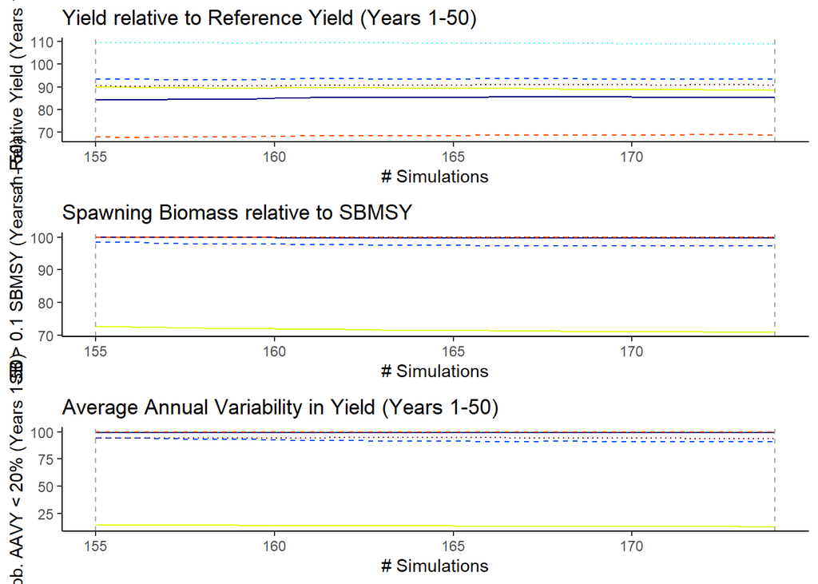

This plot confirms that enough simulations have been included in the MSE to obtain stable results.

### 3.5.2 Summarizing Performance

We can summarize the performance of the MPs with our performance metrics functions:

```r
PMlist <- c(avail("PM"), "AAVY", "P50", "PNOF")
summary(SWO_MSE, PMlist=PMlist)
```

```
#> Calculating Performance Metrics
#>                                Performance.Metrics
#> 1             Mean Short-Term Yield \n(Years 1-10)
#> 2             Mean Long-Term Yield \n(Years 41-50)
#> 3 Average Annual Variability in Yield (Years 1-50)
#> 4               Spawning Biomass relative to SBMSY
#> 5          Probability of not overfishing (F<FMSY)
#>
#> 1 Mean Short-Term Yield \n(Years 1-10)
#> 2 Mean Long-Term Yield \n(Years 41-50)
#> 3        Prob. AAVY < 20% (Years 1-50)
#> 4  Prob. SB > 0.5 SBMSY (Years 1 - 50)
#> 5        Prob. F < FMSY (Years 1 - 50)
#>
#>
#> Performance Statistics:
#>         MP   STC   LTC AAVY  P50 PNOF
#> 1 AverageC 10000 10000 0.99 0.99 0.90
#> 2   ConstC 12000 11000 0.91 0.92 0.73
#> 3   Itarg1 13000  3400 0.13 0.62 0.36
#> 4   Itarg2  6900  7700 1.00 1.00 0.98
#> 5  FMSYref 19000 12000 1.00 0.97 0.33
#> 6  SP_4010 12000  9700 0.94 0.98 0.82
```

Note that the performance statistics are calculated over all simulations in the MSE. In this case, where our OM `SWOM` includes all available SS OMs (base case and from uncertainty grid) the performance metrics are calculated across all SS OMs.

We can re-run the MSE with individual SS OMs (e.g., `OM_19`) to evaluate performance of the MPs under only those conditions.

### 3.5.3 Plotting MSE Results

There are several functions for presenting the MSE results graphically.

For example, trade-off plots with our performance metrics can be created with `TradePlot`:

```
#> Odd number of PMs. Recycling first PM
#> Recycling limits
```

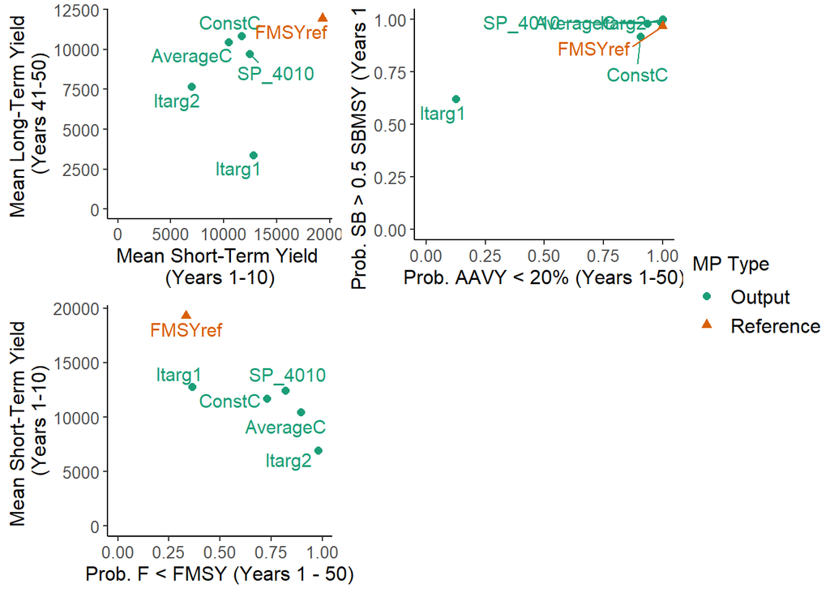

```
#>         MP   STC   LTC AAVY  P50 PNOF Satisificed
#> 1 AverageC 10000 10000 0.99 0.99 0.90        TRUE
#> 2   ConstC 12000 11000 0.91 0.92 0.73        TRUE
#> 3   Itarg1 13000  3400 0.13 0.62 0.36        TRUE
#> 4   Itarg2  6900  7700 1.00 1.00 0.98        TRUE
#> 5  FMSYref 19000 12000 1.00 0.97 0.33        TRUE
#> 6  SP_4010 12000  9700 0.94 0.98 0.82        TRUE
```

```r
TradePlot(SWO_MSE, Lims=0, PMlist=PMlist)
```

Projection plots of F/FMSY and B/BMSY for the individual simulations:

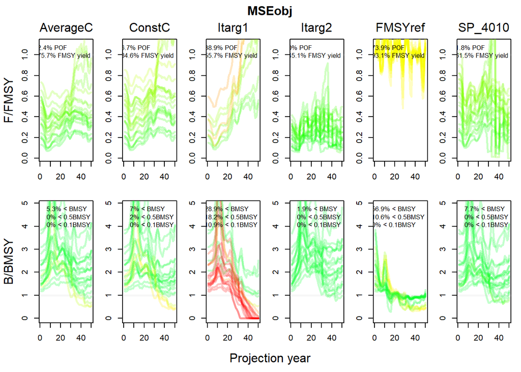

```r
Pplot(SWO_MSE)
```

Kobe-type plots:

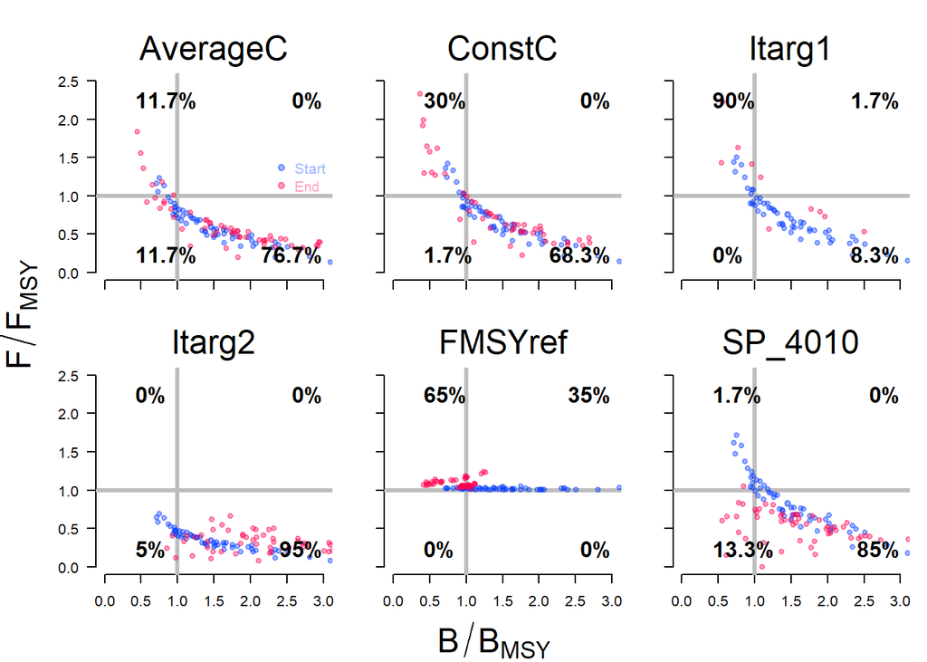

```r
Kplot(SWO_MSE)
```

and wormplots:

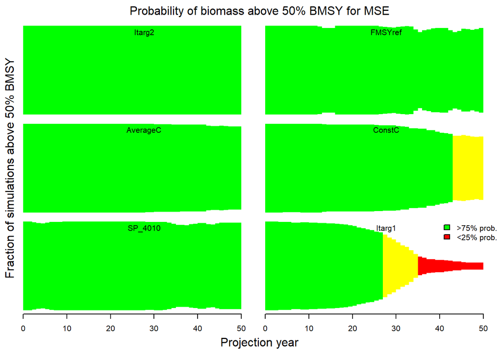

```r
wormplot(SWO_MSE)
```

## 3.6 Shiny App for Examining MSE Results

An interactive app, using the R Shiny framework, has being developed to present the MSE results. The app is under development, but working version is available for testing and development purposes:

```r
Shiny()
```